# SMekala_Assign5

Sekhar Mekala

Thursday, September 24, 2015

## Problem set 1

Given that **$A = \mbox{} \left[ \begin{array}{ccc} 1 & 0 \\ 1 & 1 \\ 1 & 3 \\ 1 & 4 \end{array} \right]$**

and **$b = \mbox{} \left[ \begin{array}{ccc} 0 \\ 8 \\ 8 \\ 20 \end{array} \right]$**

The following R code computes $AA^T$ and $A^Tb$

```r
A = matrix(c(1,0,1,1,1,3,1,4), byrow = T, nrow = 4)

print(A)
```

```
##      [,1] [,2]
## [1,]    1    0
## [2,]    1    1
## [3,]    1    3
## [4,]    1    4
```

```r
b = matrix(c(0,8,8,20), byrow = T, nrow = 4)
print(b)
```

```
##      [,1]
## [1,]    0
## [2,]    8
## [3,]    8
## [4,]   20
```

```r
#Finding transpose(A) . A
t(A) %*% A
```

```
##      [,1] [,2]
## [1,]    4    8
## [2,]    8   26
```

```r
#Finding transpose(A) . b
t(A) %*% b
```

```
##      [,1]
## [1,]   36
## [2,]  112
```

To find $\hat{x}$, we have to use the following formula:

$\hat{x} = (A^T A)^{-1} A^T b$

Here is the R code to find the $\hat{x}$

```r
x_hat <- solve(t(A) %*% A) %*% (t(A) %*% b)
print(x_hat)
```

```
##      [,1]
## [1,]    1
## [2,]    4
```

To find the error vector (represented as $\bar{\varepsilon}$) is given by the following equation:

$\bar{\varepsilon} = b - A \hat{x}$

Here is the R Code to find the error vector: $\bar{\varepsilon}$

```r
error <- b - (A %*% x_hat)
print(error)
```

```
##      [,1]
## [1,]   -1
## [2,]    3
## [3,]   -5
## [4,]    3
```

The square of the error is given by

$||\bar{\varepsilon}^2|| = ||(b - A \hat{x})^2||$

The following R code computes the squared error:

```r
sum(error^2)
```

```
## [1] 44
```

Hence the error is $||\bar{\varepsilon}||$ is $\sqrt{44} = 6.63325$

Given that **$p = \mbox{} \left[ \begin{array}{ccc} 1 \\ 5 \\ 13 \\ 17 \end{array} \right]$**

If we use $p$ in the place of $b$, then $\hat{x}$ and error will be the following (the R code and its output are given below):

```r
p <- matrix(c(1,5,13, 17), byrow = T, nrow = 4)

x_hat <- solve(t(A) %*% A) %*% (t(A) %*% p)
print(x_hat)
```

```
##      [,1]
## [1,]    1
## [2,]    4
```

```r
error <- p - (A %*% x_hat)

print(error)
```

```
##               [,1]
## [1,]  0.000000e+00
## [2,] -8.881784e-16
## [3,] -3.552714e-15
## [4,] -3.552714e-15
```

The error is **zero**, if we use $p$ matrix in the place of $b$.

Hence using linear regression, we can model the given system of equations $Ax = b$ (shown below) using the equation $b = x + 4y$.

**$A = \mbox{} \left[ \begin{array}{ccc} 1 & 0 \\ 1 & 1 \\ 1 & 3 \\ 1 & 4 \end{array} \right]$**

and **$b = \mbox{} \left[ \begin{array}{ccc} 0 \\ 8 \\ 8 \\ 20 \end{array} \right]$**

Let us find $b - p$

```r
e = b - p

error <- b - (A %*% x_hat)
```

The computed $e$ is same as the error vector, which we obtained earlier($\bar{\varepsilon}$ for $A$ and $b$)

Let us show that $e$ is orthogonal to $p$. If the dot product of $e$ and $p$ is zero, then they are orthogonal. The dot product of $e$ and $p$ is given below:

```r
sum(e * p)
```

```
## [1] 0
```

The above result shows that $e$ and $p$ are orthogonal

## Problem set 2

Reading the file’s data into a data frame:

```r
df <- read.csv("auto-mpg.data", header = F, sep = "")
head(df)
```

```
##    V1  V2   V3   V4 V5
## 1 307 130 3504 12.0 18
## 2 350 165 3693 11.5 15
## 3 318 150 3436 11.0 18
## 4 304 150 3433 12.0 16
## 5 302 140 3449 10.5 17
## 6 429 198 4341 10.0 15
```

```r
nrow(df)
```

```
## [1] 392
```

```r
names(df)
```

```
## [1] "V1" "V2" "V3" "V4" "V5"
```

The above display confirms that we have successfully read 392 records from the file into the **df** data frame. But the column names of the data frame are randomly assigned. Let us give proper column names:

```r
names(df) <- c("displacement", "horsepower", "weight", "acceleration","mpg")
```

Now let us create the $A$ and $b$ matries:

```r
#Creating A and b matrices
A <- as.matrix(cbind(df[1], df[2], df[3], df[4]))
b <- as.matrix(df[5])

#Displaying some rows of both A and B

head(A)
```

```
##      displacement horsepower weight acceleration
## [1,]          307        130   3504         12.0
## [2,]          350        165   3693         11.5
## [3,]          318        150   3436         11.0
## [4,]          304        150   3433         12.0
## [5,]          302        140   3449         10.5
## [6,]          429        198   4341         10.0
```

```r
head(b)
```

```
##      mpg
## [1,]  18
## [2,]  15
## [3,]  18
## [4,]  16
## [5,]  17
## [6,]  15
```

```r
#typeof(A)
#solve(t(A) %*% A)
```

To find $\hat{x}$, we have to use the following formula:

$\hat{x} = (A^T A)^{-1} A^T b$

Here is the R code to find the $\hat{x}$

```r
x_hat <- solve(t(A) %*% A) %*% (t(A) %*% b)
print(x_hat)
```

```
##                       mpg
## displacement -0.030037938
## horsepower    0.157115685
## weight       -0.006217883
## acceleration  1.997320955
```

So as per linear regression, we can model $mpg$ using the following equation:

$mpg = - 0.030037938 displacement + 0.157115685 horsepower - 0.006217883 weight + 1.997320955 acceleration$

I verified the above result using the **lsfit()**, as shown in the following R code:

**NOTE:** The **lsfit()** can generate a linear regression model without an intercept (unlike the **lm()** function)

```r
ls_fit <- lsfit(A, b, wt = NULL, intercept = F)
ls_fit$coefficients
```

```
## displacement   horsepower       weight acceleration
## -0.030037938  0.157115685 -0.006217883  1.997320955
```

Hence our model is correct, since we obtained the same equation using the built in function **lsfit()**

Let us determine the **error**:

The error is computed by the following formula:

$||\bar{\varepsilon}|| = ||(b - A \hat{x})||$

R code to find the error follows:

```r
error <- b - (A %*% x_hat)
head(error)
```

```
##            mpg
## [1,]  4.616218
## [2,] -0.417359
## [3,]  3.378827
## [4,] -1.057679
## [5,]  4.548870
## [6,]  3.795990
```

```r
sqrt(sum(error^2))
```

```
## [1] 114.4615
```

The above R code found the error vector $\bar{\varepsilon}$, and also computed the error, the $||\bar{\varepsilon}||$ as 114.4615

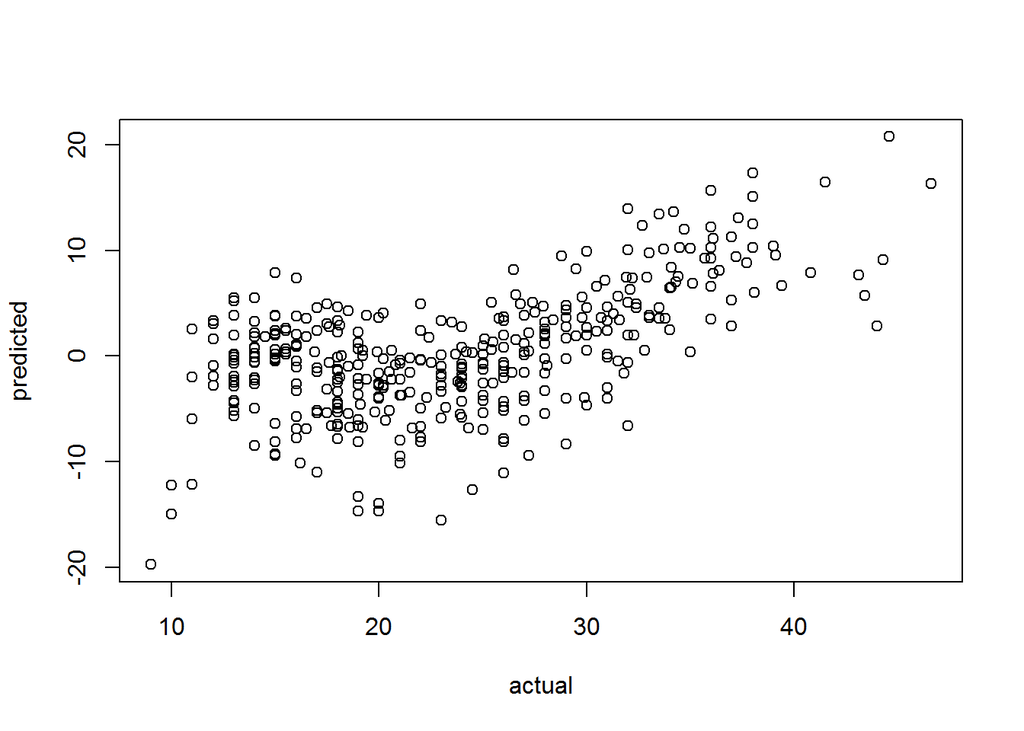

```r
plot(b,error, xlab = "actual", ylab = "predicted")
```

**Figure 1: Residual plot**

The residual plot has some pattern (but not strong), and this confirms that there is some potential to test some other models and improve the fit. The $r^2$ (the *coefficient of determination*) value is also around 71.43399%, which is good. But, we may improve this by checking other models or by eliminating insignificant variables. Given the scope of the assignment, I am not evaluating other models.

The R code to find the $r^2$ is given below:

```r
100 * var(A %*% x_hat)/var(b)
```

```
##          mpg
## mpg 71.43399
```

The $r^2$ is calculated as $100 * var(predicted) / var(actual)$

```
                                           ~~~** End of Assignment **~~~
```